# E02_Grupo5

2023-03-23

## Actividad 2 Grupo 5

Integrantes: Clemente Aguilar, Fernándo Pérez, Sergio Espinoza y Cristóbal Marchant.

```r
# Importacion de librerias
library(dplyr)
library(ggpubr)
library(xlsx)
```

```r
# Lectura de datos
data <- read.xlsx("EP02-datos.xlsx", sheetIndex = 1, stringsAsFactors = TRUE)
```

## Pregunta 1

```r
# Filtro de datos
orientales <- data %>% filter(Raza == "Oriental")
orientales_previos <- data.frame(orientales$Previo)
media_Previo <- mean(orientales_previos$orientales.Previo)
desviacion_orientales <- sd(orientales_previos$orientales.Previo)
n <- length(orientales_previos$orientales.Previo)

valor_nulo <- 19.8
alfa <- 0.05

orientales_previos
```

```
##    orientales.Previo
## 1             19.615
## 2             19.610
## 3             18.718
## 4             19.158
## 5             18.996
## 6             18.830
## 7             18.593
## 8             19.315
## 9             20.081
## 10            21.359
## 11            19.080
## 12            19.512
## 13            19.823
## 14            20.129
## 15            20.287
## 16            20.636
## 17            20.607
## 18            18.811
## 19            19.876
## 20            20.829
## 21            19.926
## 22            19.623
## 23            18.416
## 24            18.245
## 25            20.152
## 26            19.737
## 27            20.581
```

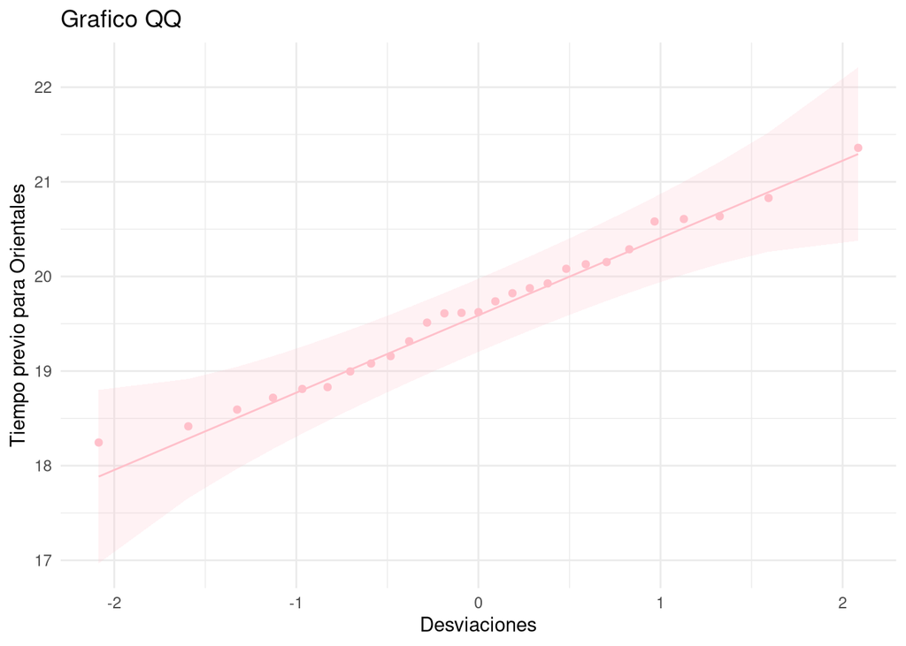

```r
# Verificar si los datos provienen de una poblacion que siga una distribucion normal
#QQ-graph
g <- ggqqplot(data = orientales_previos,
              x = "orientales.Previo",
              color = "pink",
              xlab = "Desviaciones",
              ylab = "Tiempo previo para Orientales",
              title = "Grafico QQ") + theme_minimal()

g
```

No se observan valores atipicos en el grafico, por lo que se asume que los datos de la muestra proviene de una poblacion que sigue una distribución normal.

```r
prueba_t <- t.test(orientales_previos,
                   alternative = "less",
                   mu = valor_nulo,
                   conf.level = 1 - alfa)

print(prueba_t)
```

```
##
##  One Sample t-test
##
## data:  orientales_previos
## t = -0.98585, df = 26, p-value = 0.1666
## alternative hypothesis: true mean is less than 19.8
## 95 percent confidence interval:
##      -Inf 19.90965
## sample estimates:
## mean of x
##  19.64981
```

Como el p-value es mayor que el nivel de significancia escogido, aceptamos la hipótesis nula por sobre la alternativa, indicando que el mejor tiempo medio de los atletas orientales antes de ingresar al programa de entrenamiento es igual a 19,8 segundos con un 95% de confianza.

## Pregunta 2

```r
raza_negra <- data %>% filter(Raza == "Negra")
negros_previo <- data.frame(raza_negra$Previo)
negros_posterior <- data.frame(raza_negra$Posterior)

diferencia_t <- negros_posterior - negros_previo

normalidad <-shapiro.test(diferencia_t$raza_negra.Posterior)
print(normalidad)
```

```
##
##  Shapiro-Wilk normality test
##
## data:  diferencia_t$raza_negra.Posterior
## W = 0.9781, p-value = 0.8027
```

Ho = La marca se reduce en 1.5 segundos  
Ha = la diferencia entre ambos es mayor a 1.5 segundos

```r
valor_nulo2 <- 1.5

prueba_2_muestras <- t.test(x = negros_previo$raza_negra.Previo,
                            y = negros_posterior$raza_negra.Posterior,
                            paired = TRUE,
                            alternative = "greater",
                            mu = valor_nulo2,
                            conf.level = 1 - alfa)

print(prueba_2_muestras)
```

```
##
##  Paired t-test
##
## data:  negros_previo$raza_negra.Previo and negros_posterior$raza_negra.Posterior
## t = 0.83352, df = 27, p-value = 0.2059
## alternative hypothesis: true mean difference is greater than 1.5
## 95 percent confidence interval:
##  1.431428      Inf
## sample estimates:
## mean difference
##        1.565714
```

Como el p-value es mayor que el nivel de significancia escogido, aceptamos la hipótesis nula por sobre la alternativa, indicando quese reduce en 1.5 segundos el tiempo de los atletas de raza Negra con un 95% de confianza.

Ho = Atletas negros superan a orientales por 3 segundos  
Ha = No superan por 3 segundos (puede ser > o <)

```r
valor_nulo3 <- 3

orientales_posterior <- data.frame(orientales$Posterior)

prueba_3 <- t.test(x = orientales_posterior$orientales.Posterior,
                   y = negros_posterior$raza_negra.Posterior,
                   paired = FALSE,
                   alternative = "two.sided",
                   mu = valor_nulo3,
                   conf.level = 1 - alfa)

print(prueba_3)
```

```
##
##  Welch Two Sample t-test
##
## data:  orientales_posterior$orientales.Posterior and negros_posterior$raza_negra.Posterior
## t = -2.8818, df = 50.242, p-value = 0.005803
## alternative hypothesis: true difference in means is not equal to 3
## 95 percent confidence interval:
##  1.533897 2.738127
## sample estimates:
## mean of x mean of y
##  14.68333  12.54732
```

Como el p-value resultante es menor al nivel de significancia considerado, rechazamos la hipótesis nula en favor de la hipótesis alternativa.

```r
#Diferencia de tiempo de los datos de atletas orientales
reduccion_orientales = orientales_previos - orientales_posterior
reduccion_orientales
```

```
##    orientales.Previo
## 1              4.773
## 2              4.674
## 3              4.802
## 4              5.001
## 5              5.328
## 6              5.399
## 7              5.301
## 8              4.950
## 9              5.226
## 10             5.053
## 11             4.958
## 12             5.242
## 13             5.005
## 14             4.888
## 15             4.946
## 16             5.345
## 17             4.988
## 18             4.703
## 19             4.651
## 20             4.889
## 21             4.756
## 22             5.533
## 23             5.468
## 24             5.176
## 25             4.304
## 26             4.493
## 27             4.243
```

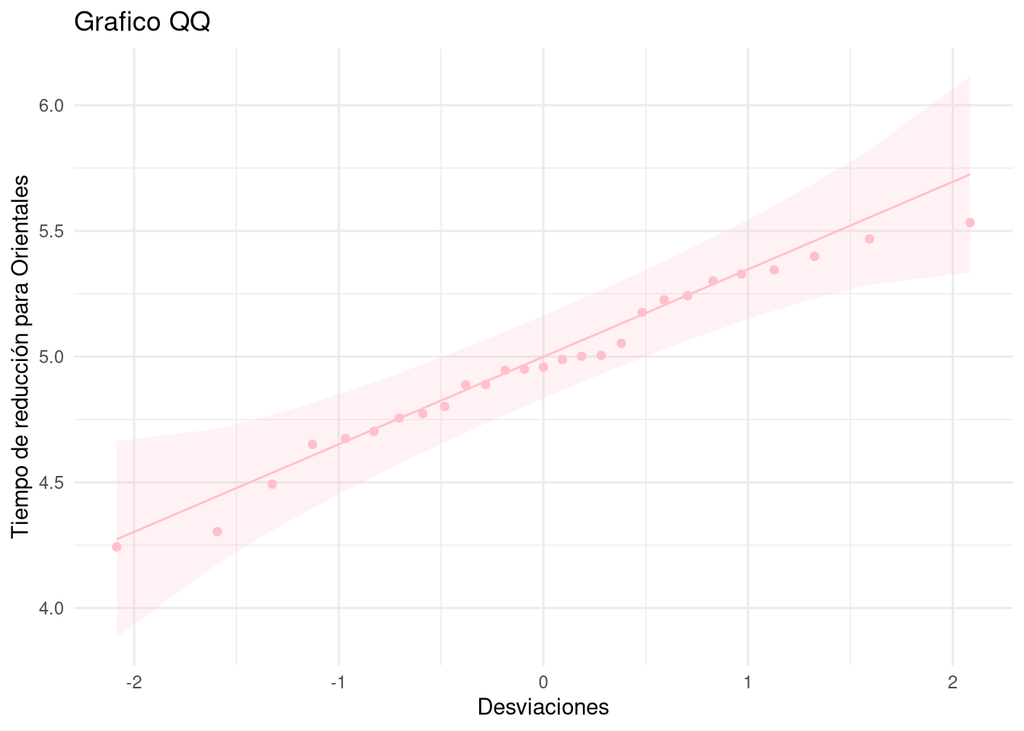

```r
# Verificar si los datos provienen de una poblacion que siga una distribucion normal
#QQ-graph
# x = "orientales.Previo" ya que la resta se guardo de esta forma.
g <- ggqqplot(data = reduccion_orientales,
              x = "orientales.Previo",
              color = "pink",
              xlab = "Desviaciones",
              ylab = "Tiempo de reducción para Orientales",
              title = "Grafico QQ") + theme_minimal()

g
```

```r
blanca <- data %>% filter(Raza == "Blanca")
blanca_previos <- data.frame(blanca$Previo)
blanca_posterior <- data.frame(blanca$Posterior)

#Diferencia de tiempo de los datos de atletas orientales
reduccion_blanca = blanca_previos - blanca_posterior
reduccion_blanca
```

```
##    blanca.Previo
## 1          2.217
## 2          3.497
## 3          3.099
## 4          3.855
## 5          2.618
## 6          2.988
## 7          3.199
## 8          3.082
## 9          2.939
## 10         3.433
## 11         2.880
## 12         2.423
## 13         2.867
## 14         3.469
## 15         2.830
## 16         2.739
## 17         4.243
## 18         3.385
## 19         2.756
## 20         2.906
## 21         2.838
## 22         3.834
## 23         2.901
## 24         3.648
## 25         2.959
## 26         2.647
```

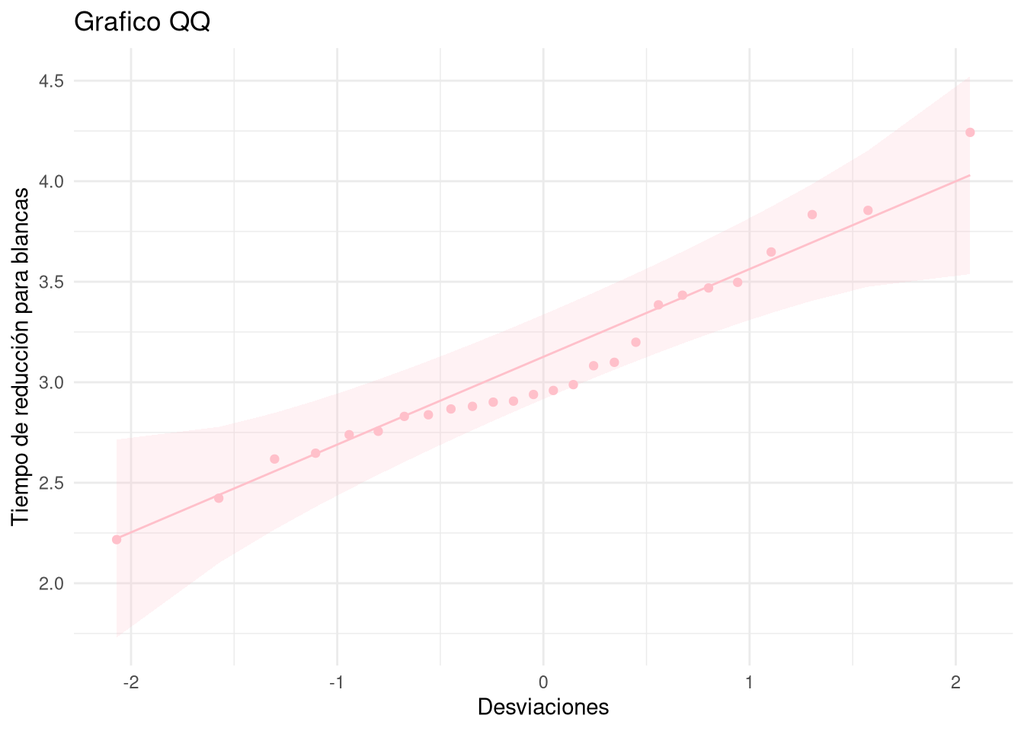

```r
# Verificar si los datos provienen de una poblacion que siga una distribucion normal
#QQ-graph
# x = "blanca.Previo" ya que la resta se guardo de esta forma.
g <- ggqqplot(data = reduccion_blanca,
              x = "blanca.Previo",
              color = "pink",
              xlab = "Desviaciones",
              ylab = "Tiempo de reducción para blancas",
              title = "Grafico QQ") + theme_minimal()

g
```

No se observan valores atípicos por parte de ambas muestras, por lo que se asume que ambas provienen de una población normal.

Se realizara una prueba para comparar las proporciones de dos grupos.

```r
n <- c(count(reduccion_orientales)$n, count(reduccion_blanca)$n)
#casos exitosos
#primero los orientales y segundo los blancos
exitos <- c(count(subset(reduccion_orientales, orientales.Previo >= 4.9))$n, count(subset(reduccion_blanca, blanca.Previo >= 3))$n)
alfa <- 0.05
prueba <- prop.test(exitos, n=n, alternative = "two.sided", conf.level = 1-alfa)
print(prueba)
```

```
##
##  2-sample test for equality of proportions with continuity correction
##
## data:  exitos out of n
## X-squared = 0.92021, df = 1, p-value = 0.3374
## alternative hypothesis: two.sided
## 95 percent confidence interval:
##  -0.1335865  0.4726178
## sample estimates:
##    prop 1    prop 2
## 0.5925926 0.4230769
```

El resultado no mostró suficiente evidencia para decir que las proporciones son distintas. Se sacó un intervalo de confianza del 95% para la diferencia entre las proporciones muestrales. Las proporciones estimadas fueron de 0.59 para los orientales y 0.42 para los blancos.